# Introduction to proteomics data analysis - MaxQuant Data Dependent Acquisition spike-in study

[figure not shown]

Figure 30. altSEE7

6. You can change the contrast by going back to the volcano plot and click on Data parameters and select e.g., `conditionratio08.pval` and `conditionratio08.logFC`. You can now again select a region in the plot to display the features in the table below. You can also ask for a panel tour…

[figure not shown]

Figure 31. altSEE8

7. Note, that the iSEE app also enables researchers to download the individual panels
   1. Click `export icon` at the top right
   2. Click `download panel output`. A new panel appears where you can select the iSEE panels for download.
   3. Click Download and you can download the output of the selected panels in a zip file
   4. When you open the zip-file you can inspect your selected output.

[figure not shown]

Figure 32. altSEE downloads 1

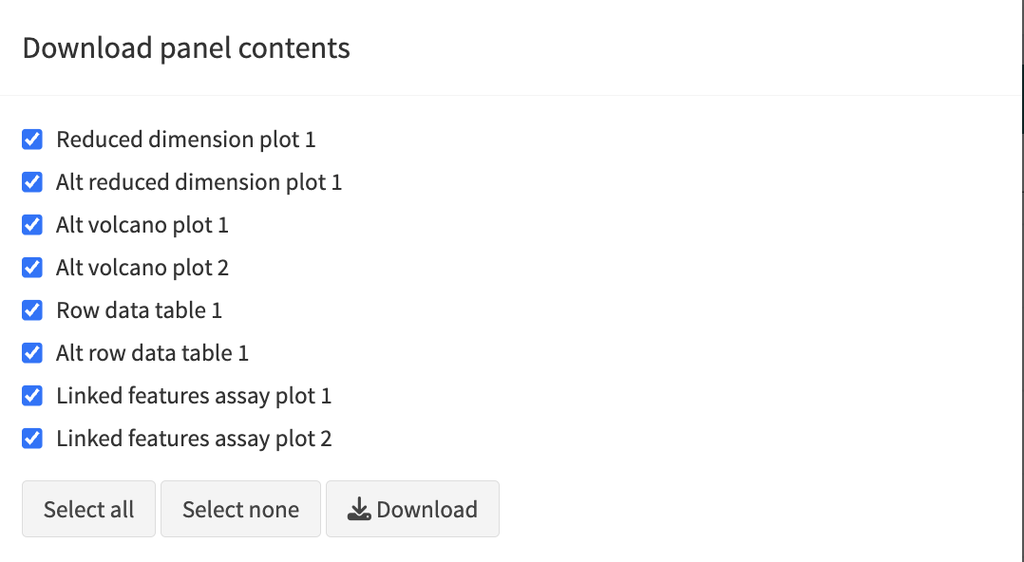

Figure 33. iSEE downloads 2

[figure not shown]

Figure 34. altSEE downloads 3

[figure not shown]

Figure 35. altSEE downloads 4

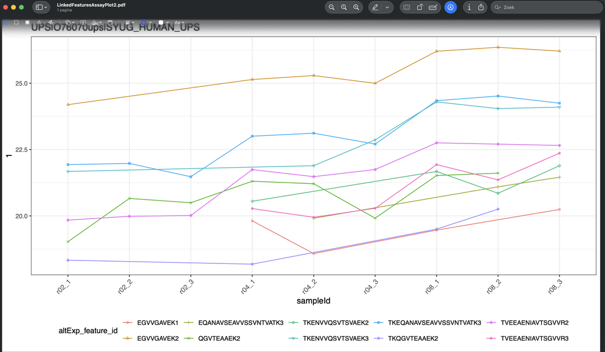

Figure 36. altSEE downloads 5

8. Interestingly, the iSEE app also enables you to download the R-code to reproduce the selected panels in R. You can copy this code in your R markdown report to include these figures there. This enables you to fully reproduce the data analysis and plots.

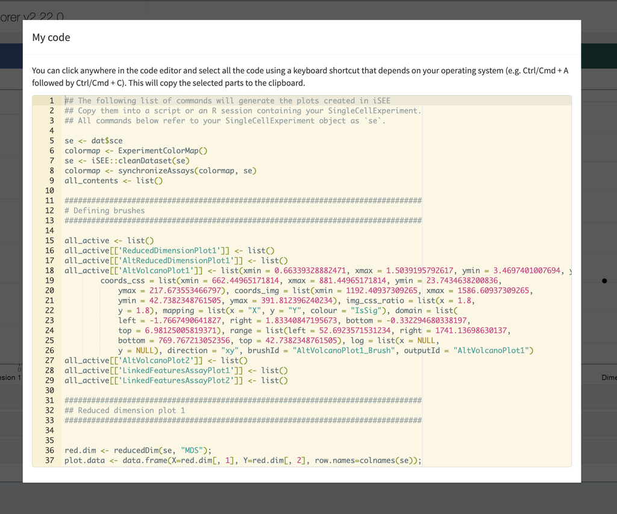

Figure 37. altSEE downloads 6

## References

Goeminne, Ludger J E, Kris Gevaert, and Lieven Clement. 2016. “Peptide-Level Robust Ridge Regression Improves Estimation, Sensitivity, and Specificity in Data-Dependent Quantitative Label-Free Shotgun Proteomics.” *Mol. Cell. Proteomics* 15 (2): 657–68.

Goeminne, Ludger, Adriaan Sticker, Lennart Martens, Kris Gevaert, and Lieven Clement. 2020. “MSqRob Takes the Missing Hurdle: Uniting Intensity- and Count-Based Proteomics.” *Analytical Chemistry* 92 (9): 6278–87. https://doi.org/10.1021/acs.analchem.9b04375.

Sticker, Adriaan, Ludger Goeminne, Lennart Martens, and Lieven Clement. 2020. “Robust Summarization and Inference in Proteome-Wide Label-Free Quantification.” *Mol. Cell. Proteomics* 19 (7): 1209–19.

Vandenbulcke, Stijn, Christophe Vanderaa, Oliver Crook, Lennart Martens, and Lieven Clement. 2025. “Msqrob2TMT: Robust Linear Mixed Models for Inferring Differential Abundant Proteins in Labeled Experiments with Arbitrarily Complex Design.” *Mol. Cell. Proteomics* 24 (7): 101002.